# Problem Set 1 -EDV

Blake Hartung, Zhisen Cai, Yuxin Cui

23 Spetember 2021

```r
library(tidyverse)
library(gridExtra)

### problem 1
# Load fastfood dataset from openintro
library(openintro)
data(fastfood)

# Horizontal boxplots categorized by restaurant
boxplot_by_rest <- ggplot(fastfood, aes(x=calories,
                                        y=reorder(restaurant, calories, median))) +
  geom_boxplot(fill="gray") +
  ylab("restaurant") +
  theme_minimal()

most_caloric <-  fastfood %>%
  filter(calories == max(calories)) %>%
  select(item)

# create hist
histograms <- ggplot(fastfood, aes(x=calories)) +
  geom_histogram(binwidth = 200, fill="gray", color="black") +
  facet_grid(restaurant ~ .) +
  ylab("") +
  theme_minimal()

# filter the fastfood df to only contain crispy or grilled items
crisp <- fastfood %>%
  filter((str_detect(item, "Crispy")) == T) %>%
  mutate(cooktype = "Crispy")

grilled <- fastfood %>%
  filter((str_detect(item, "Grilled")) == T) %>%
  mutate(cooktype = "Grilled")

# append the two dataframes together
crisp_and_grilled <- rbind(crisp, grilled)

# create density plot
dens_comparison <- ggplot(crisp_and_grilled, aes(x=calories,
                                                 color=cooktype,
                                                 fill=cooktype)) +
  geom_density(alpha=0.2)

### problem 2
data(mtl)

gg_hist <- ggplot(mtl) +
  geom_histogram(aes(x=asubic),
                 fill="gray",
                 color="black")

gg_left <- ggplot(mtl) +
  geom_histogram(aes(x = age),
                 fill = "gray",
                 color = "black",
                 binwidth = 5,
                 boundary = 40,
                 closed = "left") +
  scale_x_continuous(breaks = seq(40, 80, by = 5)) +
  ggtitle("Right Open")

gg_right <- ggplot(mtl) +
  geom_histogram(aes(x = age),
                 fill = "gray",
                 color = "black",
                 binwidth = 5,
                 boundary = 40,
                 closed = "right") +
  scale_x_continuous(breaks = seq(40, 80, by = 5)) +
  ggtitle("Right Closed")

# change boundary to just above the discrete value so now boundary value is included
gg_left_changed <- ggplot(mtl) +
  geom_histogram(aes(x = age),
                 fill = "gray",
                 color = "black",
                 binwidth = 5,
                 boundary = 40.01,
                 closed = "left") +
  scale_x_continuous(breaks = seq(40, 80, by = 5)) +
  ggtitle("Right open Adjusted")


### Problem 3
library(agridat)
data(australia.soybean)
library(qqplotr)
library(gridExtra)
# we have to do it seperatedly since mu and sigma^2 are different for each different loc
# filter data by location
d1 = filter(australia.soybean, loc == "Lawes")
d2 = filter(australia.soybean, loc == "Brookstead")
d3 = filter(australia.soybean, loc == "Nambour")
d4 = filter(australia.soybean, loc == "RedlandBay")

p1 <- ggplot(data =d1, mapping = aes(sample = yield))+stat_qq_band()+stat_qq_point()+stat_qq_line()+xlab("theoretical Quantiles")+ylab("Sample Quantiles")+ggtitle("Lawes")
p2 <- ggplot(data =d2, mapping = aes(sample = yield))+stat_qq_band()+stat_qq_point()+stat_qq_line()+xlab("theoretical Quantiles")+ylab("Sample Quantiles")+ggtitle("Brookstead")
p3 <- ggplot(data =d3, mapping = aes(sample = yield))+stat_qq_band()+stat_qq_point()+stat_qq_line()+xlab("theoretical Quantiles")+ylab("Sample Quantiles")+ggtitle("Nambour")
p4 <- ggplot(data =d4, mapping = aes(sample = yield))+stat_qq_band()+stat_qq_point()+stat_qq_line()+xlab("theoretical Quantiles")+ylab("Sample Quantiles")+ggtitle("RedlandBay")

# create the histograms with density plots
library(ggh4x)
p5 <-ggplot(d1,aes(x=yield))+
  geom_histogram(aes(y = stat(density)))+
  geom_density(aes(y = after_stat(density)),color = "red")+
  stat_function(fun = function(x){dnorm(x, mean = mean(d1$yield), sd = sd(d1$yield))},color='blue')+
  ggtitle("Lawes")
p6 <-ggplot(d2,aes(x=yield))+
  geom_histogram(aes(y = stat(density)))+
  geom_density(aes(y = after_stat(density)),color = "red")+
  stat_function(fun = function(x){dnorm(x, mean = mean(d2$yield), sd = sd(d2$yield))},color='blue')+
  ggtitle("Brookstead")
p7 <-ggplot(d3,aes(x=yield))+
  geom_histogram(aes(y = stat(density)))+
  geom_density(aes(y = after_stat(density)),color = "red")+
  stat_function(fun = function(x){dnorm(x, mean = mean(d3$yield), sd = sd(d3$yield))},color='blue')+
  ggtitle("Nambour")
p8 <-ggplot(d4,aes(x=yield))+
  geom_histogram(aes(y = stat(density)))+
  geom_density(aes(y = after_stat(density)),color = "red")+
  stat_function(fun = function(x){dnorm(x, mean = mean(d4$yield), sd = sd(d4$yield))},color='blue')+
  ggtitle("RedlandBay")
# shapiro-wilk tests (This function produces a test statistic W along with
# a corresponding p-value. If the p-value is less than a =.05, there is
# sufficient evidence to say that the sample does not come from a population
# that is normally distributed.)

lawes_shap <- round(shapiro.test(d1$yield)$p.value, 4)
brookstead_shap <- round(shapiro.test(d2$yield)$p.value, 4)
nambour_shap <- round(shapiro.test(d3$yield)$p.value, 4)
redlandbay_shap <- round(shapiro.test(d4$yield)$p.value, 4)

### problem 4
# import breslow from boot
library(boot)
data(breslow)

# Mutate dataset for labelling purposes
breslow_mutate <- breslow %>%
  mutate(labeled = ifelse(smoke == 1, "Smoker", "Non-Smoker"))

# plot the comparison, make sure the y limits are the same for comparison
death_comparison <- ggplot(breslow_mutate, aes(x=age, y=y)) +
  geom_col() +
  ylim(0, 215) +
  xlab("Age (midpoint of 10 yr bins)") +
  ylab("Deaths due to Coronary Artery Disease") +
  facet_wrap(labeled ~ .)

### problem 5
library(ggridges)
data(loans_full_schema)

# create a histogram with a density plot in order to describe the distribution
quick_histogram <- ggplot(loans_full_schema,aes(x=loan_amount))+
  geom_histogram(binwidth = 2500, aes(y = stat(density)),fill='gray', color='black')+
  geom_density(aes(y = after_stat(density)),color = "red")+
  stat_function(fun = function(x){dnorm(x, mean = mean(loans_full_schema$loan_amount), sd = sd(loans_full_schema$loan_amount))},color='blue')


boxplot_data <- ggplot(loans_full_schema,
                       aes(x=loan_amount,
                           y=reorder(loan_purpose, loan_amount, median))) +
  geom_boxplot() +
  ylab("Loan Purpose") +
  xlab("Loan Amount")

ridge_data <- ggplot(loans_full_schema,
                     aes(x=loan_amount,
                         y=reorder(loan_purpose, loan_amount, median))) +
  geom_density_ridges(bandwidth=2500) +
  ylab("Loan Purpose") +
  xlab("Loan Amount")
```

## 1. Fast Food

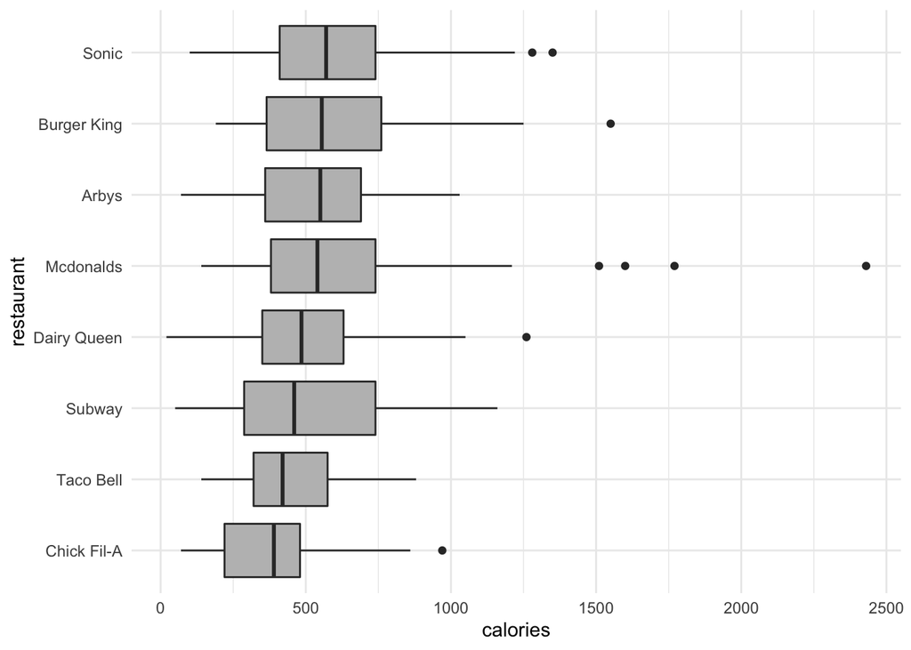

```r
boxplot_by_rest
```

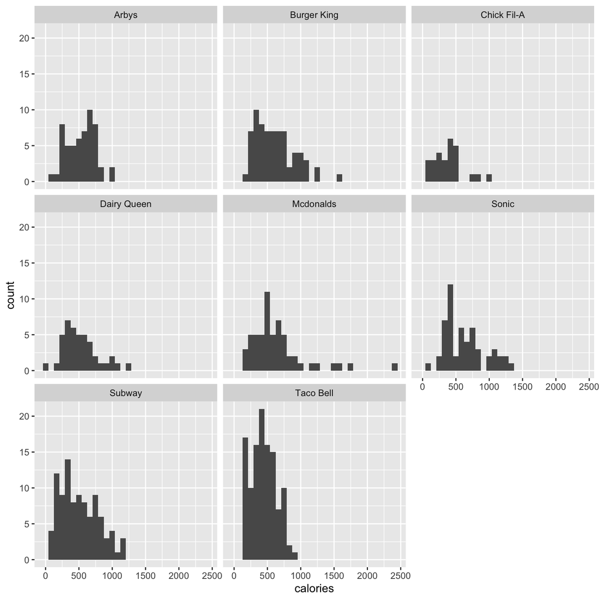

```r
ggplot(data=fastfood, aes(x=calories)) + geom_histogram()+facet_wrap(~restaurant)
```

The biggest insight we found was the sheer amount of menu items that Taco Bell has, especially in comparison to a place like Chick-fil-a. This tends to be the problem with boxplots in general too, often not showing the number of data points included in each plot effectively.

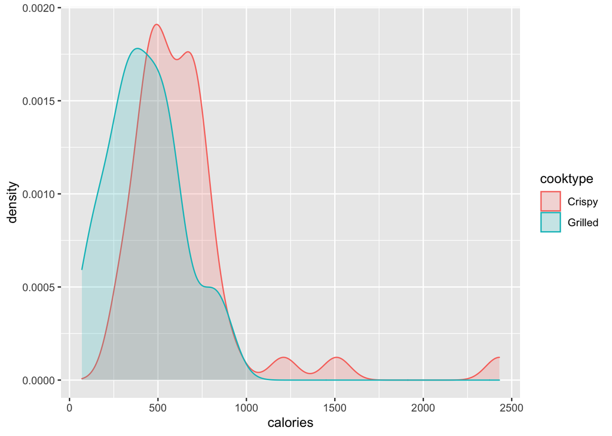

```r
dens_comparison
```

As one might expect, there is a pretty clearly higher average calories per meal for items including “crispy”. It is closer than one might expect though, most likely due to the inclusion of a large amount of similar ingredients, such as buns, sauces, toppings, et cetra.

## 2. Temporal Lobes

### ggplot2

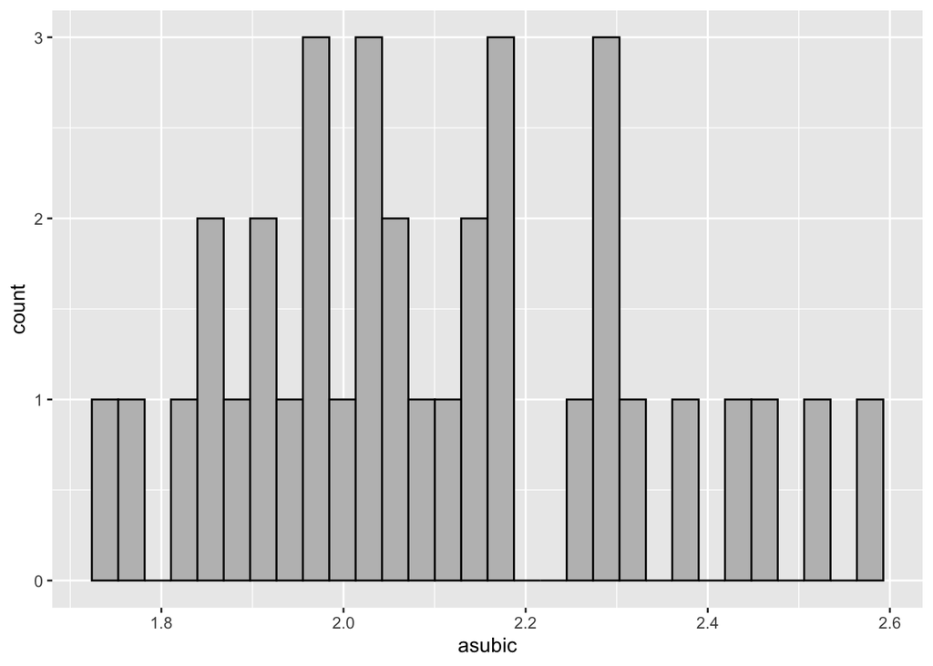

```r
gg_hist
```

### base

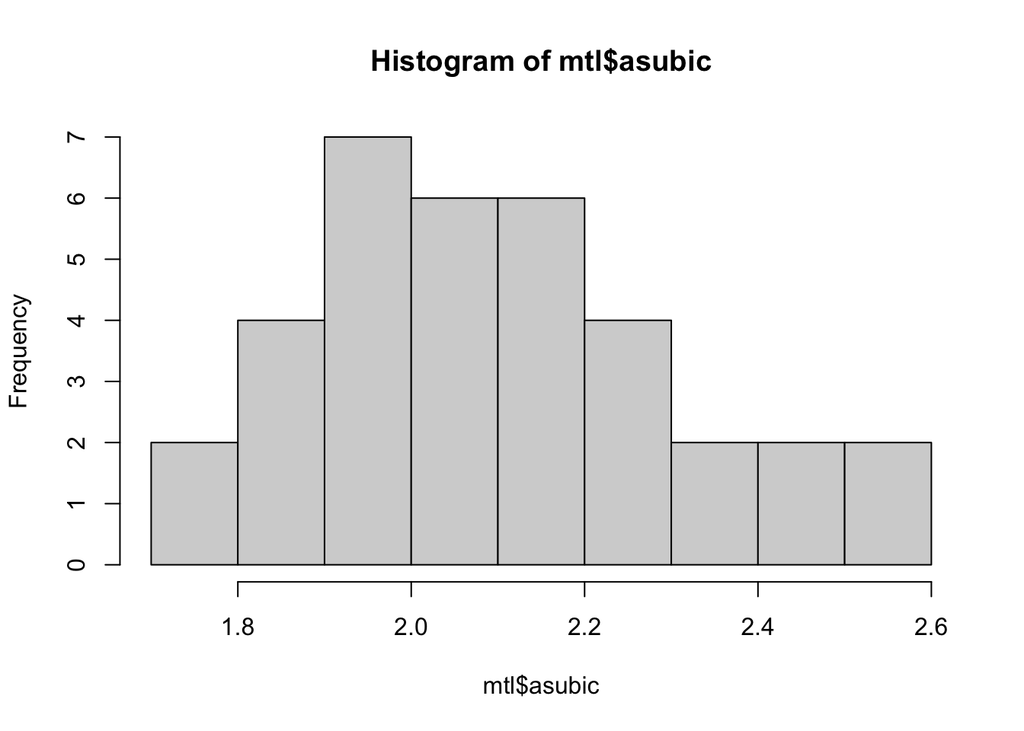

```r
hist(mtl$asubic)
```

The default histogram for this dataset is a much better choice, as the ggplot default creates the histogram with 30 bins, something that is not a good choice for most datasets. The base R hist(), after testing, seems to try to fit 20-30% of the data into the most populous bin, deciding on a binwidth from there.

Using sturge rule with formula k = 1+ log(n), k=6.12

### Left Closed

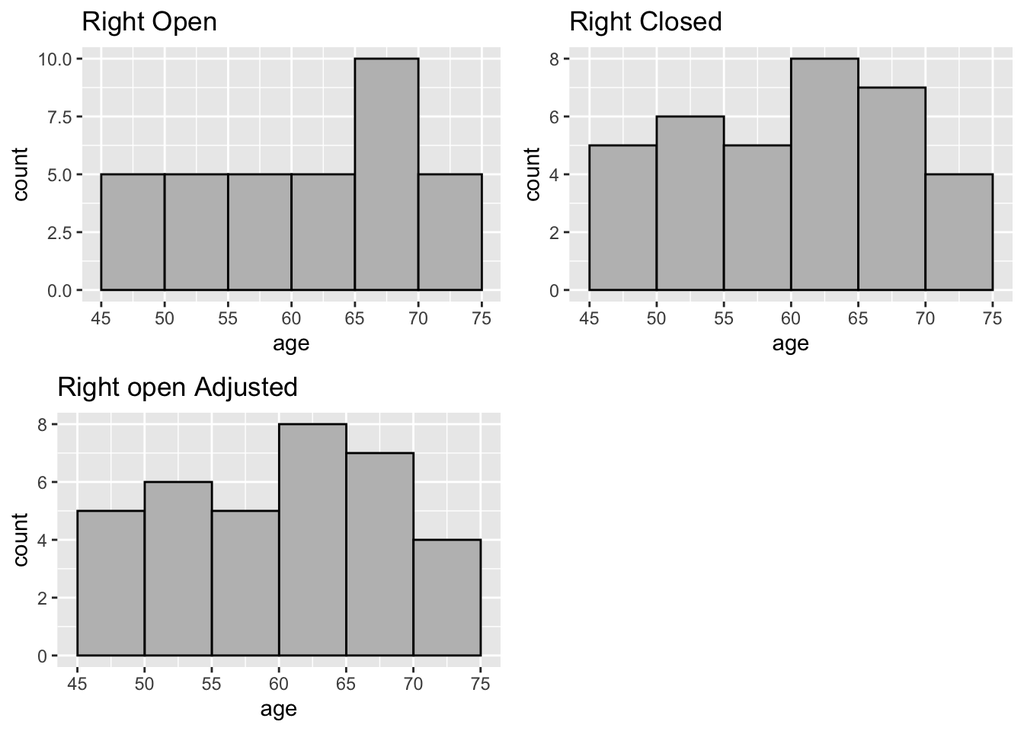

```r
grid.arrange(gg_left, gg_right, gg_left_changed, nrow=2)
```

Even though the bottom histogram is right open, I was able to make it right closed by changing the boundary value to marginally above 40 (here 40.01 did the trick). The two histograms look identical to the eye, and since the age data are all discrete, it wouldn’t have any lasting effect on the visualization if more data was added.

## 3. Soybeans

### QQ Plots

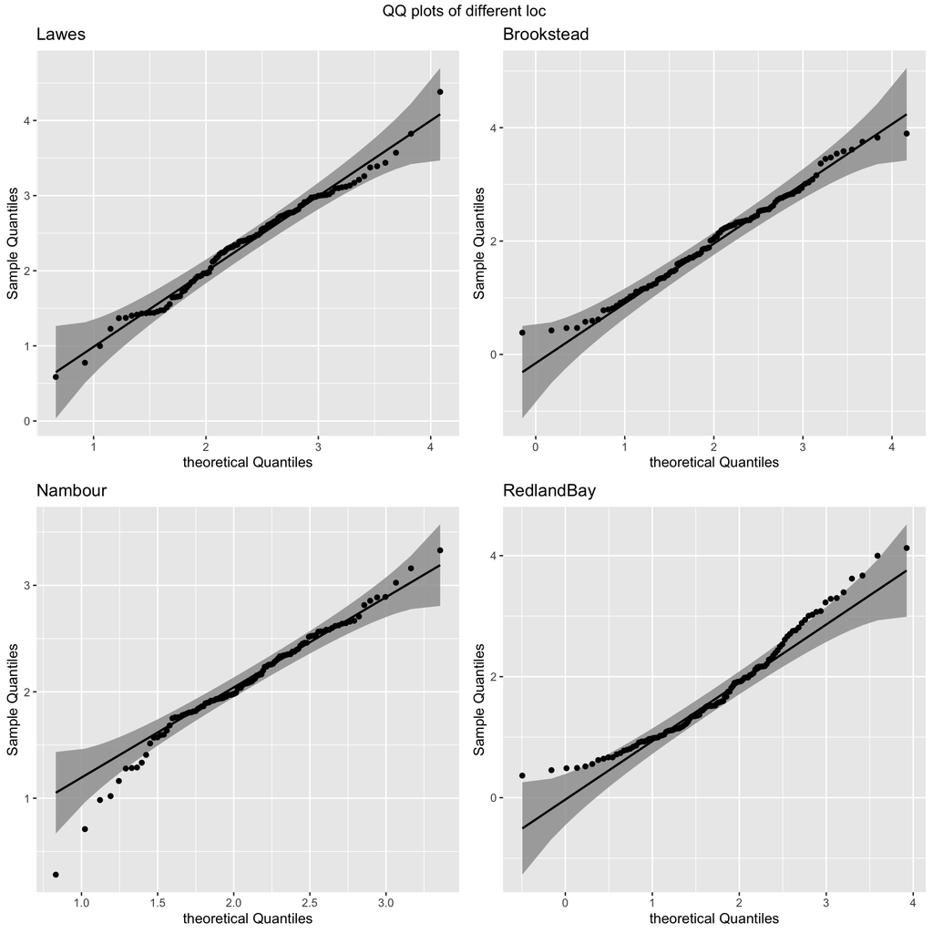

```r
grid.arrange(p1,p2,p3,p4,nrow = 2,top = "QQ plots of different loc ")
```

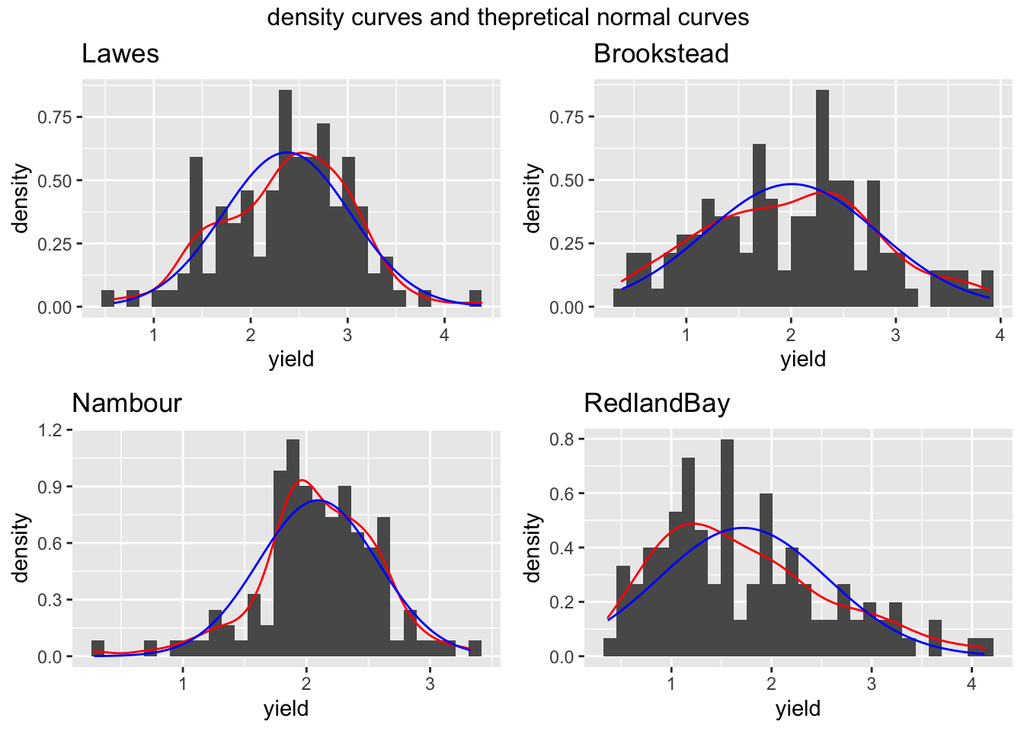

```r
grid.arrange(p5,p6,p7,p8,nrow = 2,top = "density curves and thepretical normal curves ")
```

$H_0$ : the yield of this location is normally distributed $H_a$ : the yield of this location is not normally distributed

For the most part I beleive these results are consistent. Nambour and Redland bay do not meet the threshold to be considered normal distributions by the Shapiro-Walkes Test, as is easily verifiable by looking at their histogram and density plots, where Brookstead and Lawes do meet the threshold, each of which look much more evenly distributed on both sides of the median. The QQ Plots maintain these notions, where Redland Bay looks slighly exponential and Nambour looks slightly like a root graph, representing their data distribution well.

## 4. Doctors

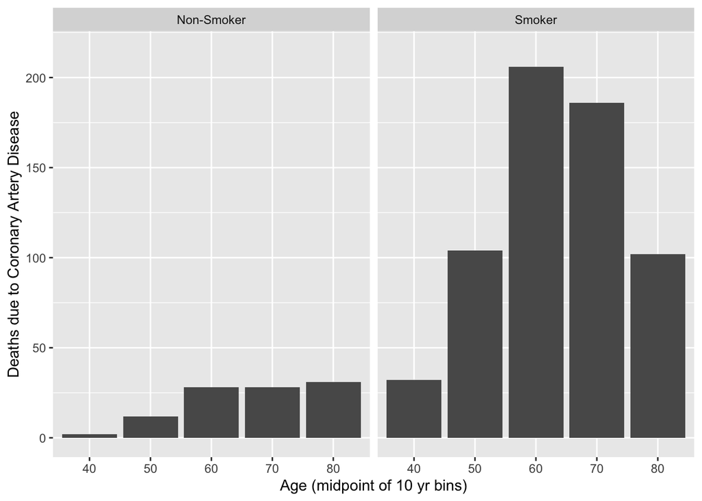

```r
death_comparison
```

## 5. Loans

### Loan Amount Histogram

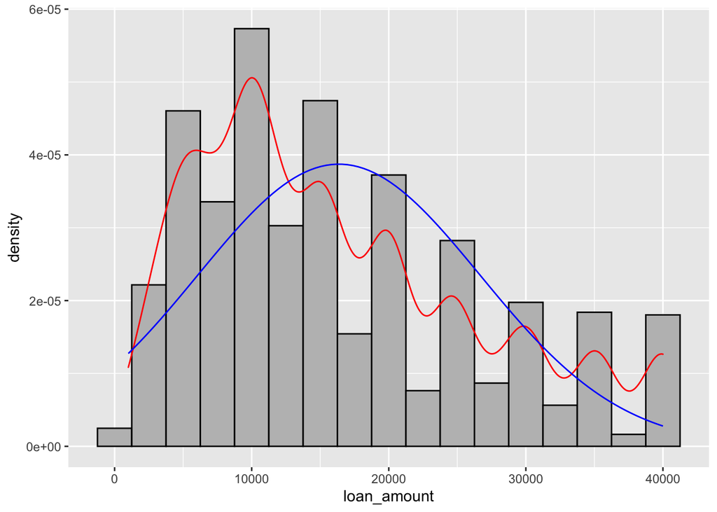

```r
quick_histogram
```

Generally, the histogram shows us that loans given out quickly peak at 10,000 dollars, then falling off as the loan amount get higher. The density plot is very telling here as well. After the 10,000 dollar mark, it is clear that loans are predominantly given out in 5,000 dollar increments, entirely due to the convenience and precedent set of taking larger loans (keep the loans in multiples of 5K).

### Boxplots

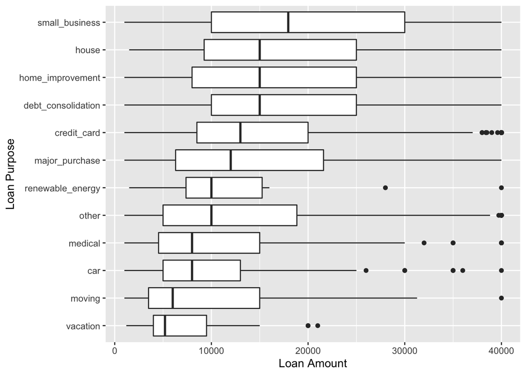

```r
boxplot_data
```

### Ridgeline Plots

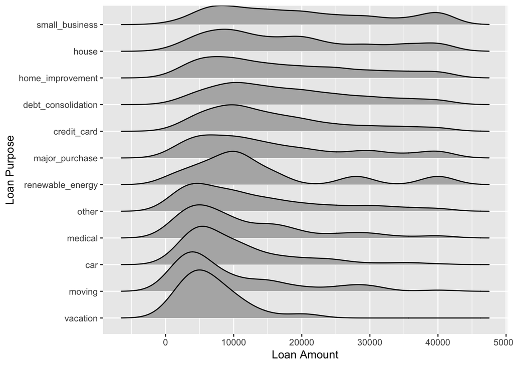

```r
ridge_data
```

# compare two plots We believe the boxplots do a much better job here. They have a clearly stated median to go off of for each loan purpose, which is arguably the biggest stat we can take from the data at hand. It is also very nice and clear to see the outliers of the dataset.